# Practical Machine Learning Course Notes

Xing Su

$\pagebreak$

## Prediction

- **process for prediction** = population $\rightarrow$ probability and sampling to pick set of data $\rightarrow$ split into training and test set $\rightarrow$ build prediction function $\rightarrow$ predict for new data $\rightarrow$ evaluate
  - **Note**: choosing the right dataset and knowing what the specific question is are paramount to the success of the prediction algorithm (GoogleFlu failed to predict accurately when people’s search habits changed)

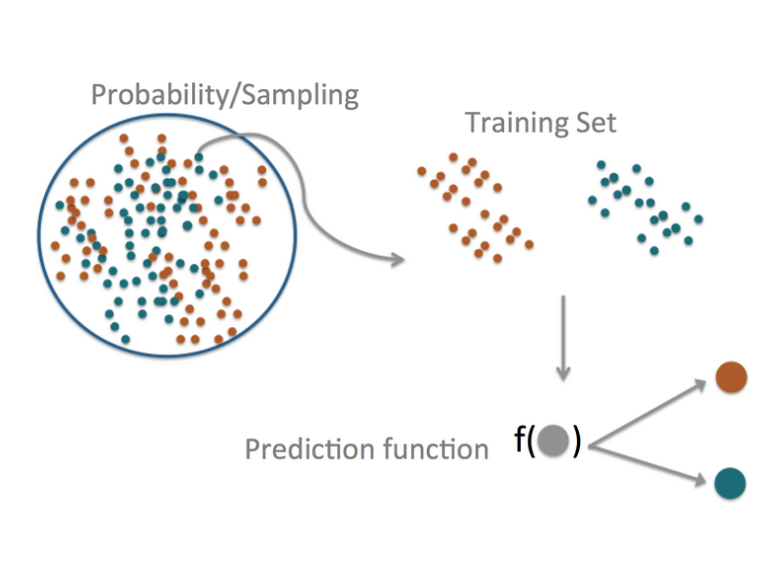

- **components of predictor** = question $\rightarrow$ input data $\rightarrow$ features *(extracting variables/characteristics)* $\rightarrow$ algorithm $\rightarrow$ parameters *(estimate)* $\rightarrow$ evaluation
- **relative order of importance** = question (concrete/specific) **>** data (relevant) **>** features (properly extract) **>** algorithms
- **data selection**
  - **Note**: “garbage in = garbage out” $\rightarrow$ having the correct/relevant data will decide whether the model is successful
  - data for what you are trying to predict is most helpful
  - more data $\rightarrow$ better models (usually)
- **feature selection**
  - good features $\rightarrow$ lead to data compression, retain relevant information, created based on expert domain knowledge
  - common mistakes $\rightarrow$ automated feature selection (can yield good results but likely to behave inconsistently with slightly different data), not understanding/dealing with skewed data/outliers, throwing away information unnecessarily
- **algorithm selection**
  - matter less than one would expect
  - getting a sensible approach/algorithm will be the basis for a successful prediction
  - more complex algorithms can yield incremental improvements
  - ideally *interpretable* (simple to explain), accurate, scalable/fast (may leverage parallel computation)
- prediction is effectively about *trade-offs*
  - find the correct balance between interpretability vs accuracy vs speed vs simplicity vs scalability
  - *interpretability* is especially important in conveying how features are used to predict outcome
  - scalability is important because for an algorithm to be of practical use, it needs to be implementable on large datasets without incurring large costs (computational complexity/time)

### In Sample vs Out of Sample Errors

- **in sample error** = error resulted from applying your prediction algorithm to the dataset you built it with
  - also known as *resubstitution error*
  - often optimistic (less than on a new sample) as the model may be tuned to error of the sample
- **out of sample error** = error resulted from applying your prediction algorithm to a new data set
  - also known as *generalization error*
  - out of sample error most important as it better evaluates how the model should perform
- in sample error **<** out of sample error
  - reason is *over-fitting*: model too adapted/optimized for the initial dataset
    - data have two parts: *signal* vs *noise*
    - goal of predictor (should be simple/robust) = find signal
    - it is possible to design an accurate in-sample predictor, but it captures both signal and noise
    - predictor won’t perform as well on new sample
  - often times it is better to give up a little accuracy for more robustness when predicting on new data
- *example*

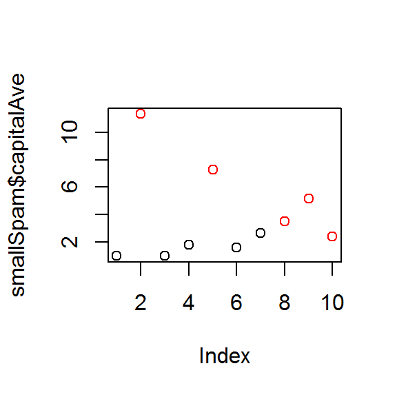

```r
# load data
library(kernlab); data(spam); set.seed(333)
# picking a small subset (10 values) from spam data set
smallSpam <- spam[sample(dim(spam)[1],size=10),]
# label spam = 2 and ham = 1
spamLabel <- (smallSpam$type=="spam")*1 + 1
# plot the capitalAve values for the dataset with colors differentiated by spam/ham (2 vs 1)
plot(smallSpam$capitalAve,col=spamLabel)
```

```r
# first rule (over-fitting to capture all variation)
rule1 <- function(x){
    prediction <- rep(NA,length(x))
    prediction[x > 2.7] <- "spam"
    prediction[x < 2.40] <- "nonspam"
    prediction[(x >= 2.40 & x <= 2.45)] <- "spam"
    prediction[(x > 2.45 & x <= 2.70)] <- "nonspam"
    return(prediction)
}
# tabulate results of prediction algorithm 1 (in sample error -> no error in this case)
table(rule1(smallSpam$capitalAve),smallSpam$type)
```

```
##
##           nonspam spam
##   nonspam       5    0
##   spam          0    5
```

```r
# second rule (simple, setting a threshold)
rule2 <- function(x){
    prediction <- rep(NA,length(x))
    prediction[x > 2.8] <- "spam"
    prediction[x <= 2.8] <- "nonspam"
    return(prediction)
}
# tabulate results of prediction algorithm 2(in sample error -> 10% in this case)
table(rule2(smallSpam$capitalAve),smallSpam$type)
```

```
##
##           nonspam spam
##   nonspam       5    1
##   spam          0    4
```

```r
# tabulate out of sample error for algorithm 1
table(rule1(spam$capitalAve),spam$type)
```

```
##
##           nonspam spam
##   nonspam    2141  588
##   spam        647 1225
```

```r
# tabulate out of sample error for algorithm 2
table(rule2(spam$capitalAve),spam$type)
```

```
##
##           nonspam spam
##   nonspam    2224  642
##   spam        564 1171
```

```r
# accuracy and total correct for algorithm 1 and 2
rbind("Rule 1" = c(Accuracy = mean(rule1(spam$capitalAve)==spam$type),
    "Total Correct" = sum(rule1(spam$capitalAve)==spam$type)),
    "Rule 2" = c(Accuracy = mean(rule2(spam$capitalAve)==spam$type),
    "Total Correct" = sum(rule2(spam$capitalAve)==spam$type)))
```

```
##         Accuracy Total Correct
## Rule 1 0.7315801          3366
## Rule 2 0.7378831          3395
```

$\pagebreak$

## Prediction Study Design

- **procedures**
  1. define error rate (type I/type II)
  2. split data into:
     - training, testing, validation (optional)
  3. pick features from the training set
     - use cross-validation
  4. pick prediction function (model) on the training set
     - use cross-validation
  5. if no validation set
     - apply **1 time** to test set
  6. if there is a validation set
     - apply to test set and refine
     - apply **1 time** to validation
  - **Note**: it’s important to hold out an untouched sample to accurately estimate the out of sample error rate
- benchmarks (i.e. set all variables = 0) can help pinpoint/test the model to see what is wrong with the model
- avoid small sample sizes
  - consider binary outcomes (i.e. coin flip)
  - for n = 1, the probability of perfect classification (100% accuracy) is 50%
  - for n = 10, the probability of perfect classification (100% accuracy) is 0.1%
  - so it’s important to have bigger samples so that when you do get a high accuracy, it may actually be a significant result and not just by chance
- *example: Netflix rating prediction competition*
  - split data between training and “held-out”
    - held-out included probe, quiz and test sets
    - probe is used to test the predictor built from the training dataset
    - quiz is used to realistically evaluate out of sample error rates
    - test is used to finally evaluate the validity of algorithm
  - important to not tune model to quiz set specifically

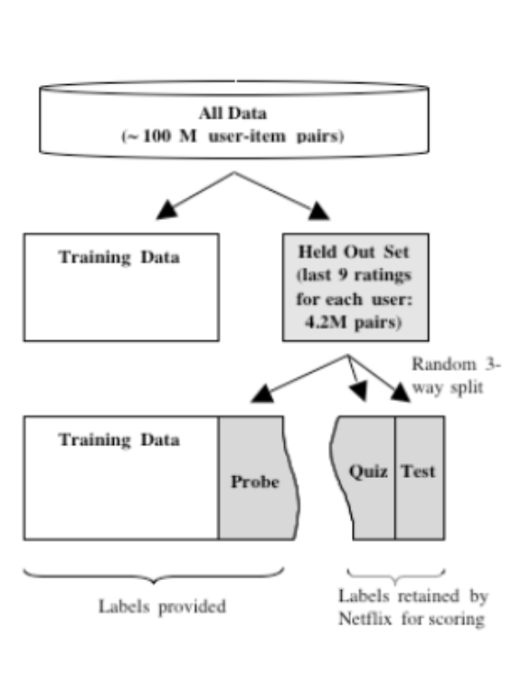

### Sample Division Guidelines for Prediction Study Design

- for large sample sizes
  - 60% training
  - 20% test
  - 20% validation
- for medium sample sizes
  - 60% training
  - 40% test
  - no validation set to refine model (to ensure test set is of sufficient size)
- for small sample sizes
  - carefully consider if there are enough sample to build a prediction algorithm
  - no test/validation sets
  - perform cross validation
  - report caveat of small sample size and highlight the fact that the prediction algorithm has never been tested for out of sample error
- there should always be a test/validation set that is held away and should *NOT* be looked at when building model
  - when complete, apply the model to the held-out set only one time
- *randomly sample* training and test sets
  - for data collected over time, build training set in chunks of times
- datasets must reflect structure of problem
  - if prediction evolves with time, split train/test sets in time chunks (known as *backtesting* in finance)
- subsets of data should reflect as much diversity as possible

### Picking the Right Data

- use like data to predict like
- to predict a variable/process X, use the data that’s as closely related to X as possible
- weighting the data/variables by understanding and intuition can help to improve accuracy of prediction
- data properties matter $\rightarrow$ knowing how the data connects to what you are trying to measure
- predicting on unrelated data is the most common mistake
  - if unrelated data must be used, be careful about interpreting the model as to why it works/doesn’t work

$\pagebreak$

## Types of Errors

- when discussing the outcome decided on by the algorithm, **Positive** = identified and **negative** = rejected
  - **True positive** = correctly identified (predicted true when true)
  - **False positive** = incorrectly identified (predicted true when false)
  - **True negative** = correctly rejected (predicted false when false)
  - **False negative** = incorrectly rejected (predicted false when true)
- **example: medical testing**
  - *True positive* = Sick people correctly diagnosed as sick
  - *False positive* = Healthy people incorrectly identified as sick
  - *True negative* = Healthy people correctly identified as healthy
  - *False negative* = Sick people incorrectly identified as healthy

### Notable Measurements for Error – Binary Variables

- **accuracy** = weights false positives/negatives equally
- **concordance** = for multi-class cases,
  $$\kappa = \frac{accuracy - P(e)}{1 - P(e)}$$
  where
  $$P(e) = \frac{TP+FP}{total} \times \frac{TP+FN}{total} + \frac{TN+FN}{total} \times \frac{FP+TN}{total}$$

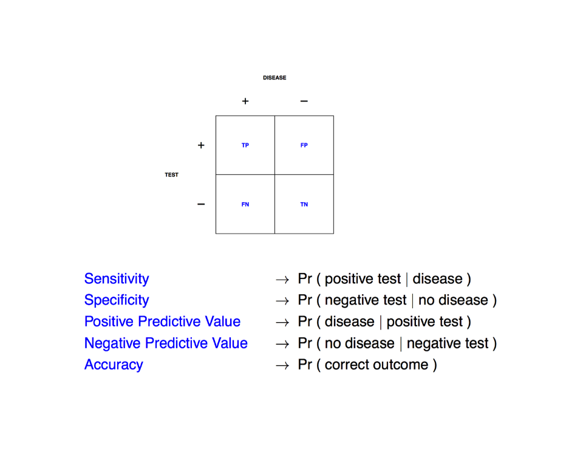

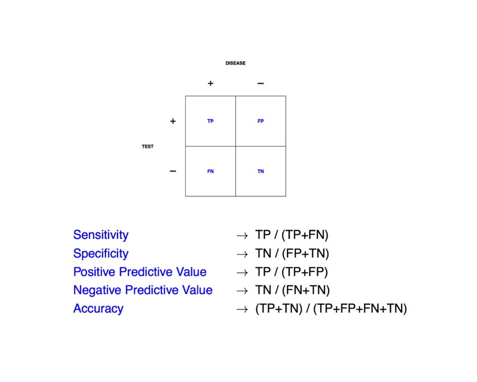

- *example*
  - given that a disease has 0.1% prevalence in the population, we want to know what’s probability of a person having the disease given the test result is positive? the test kit for the disease is 99% sensitive (most positives = disease) and 99% specific (most negatives = no disease)
  - what about 10% prevalence?

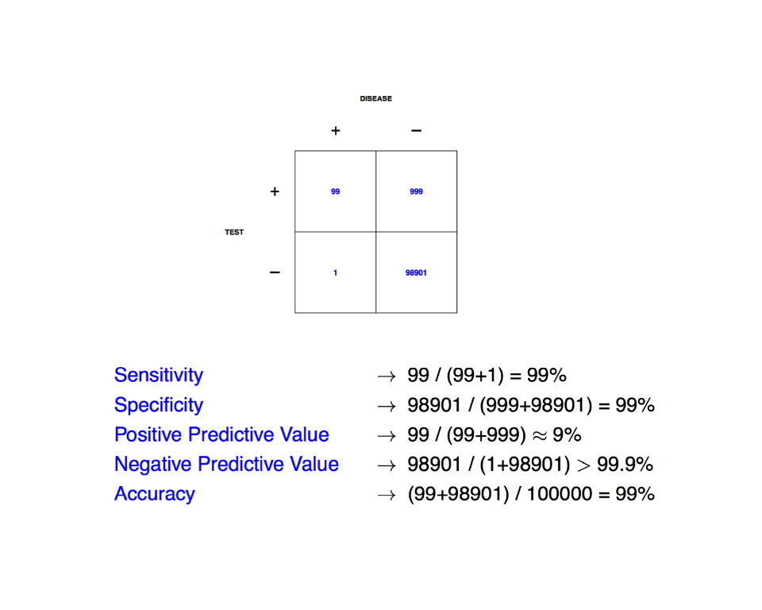

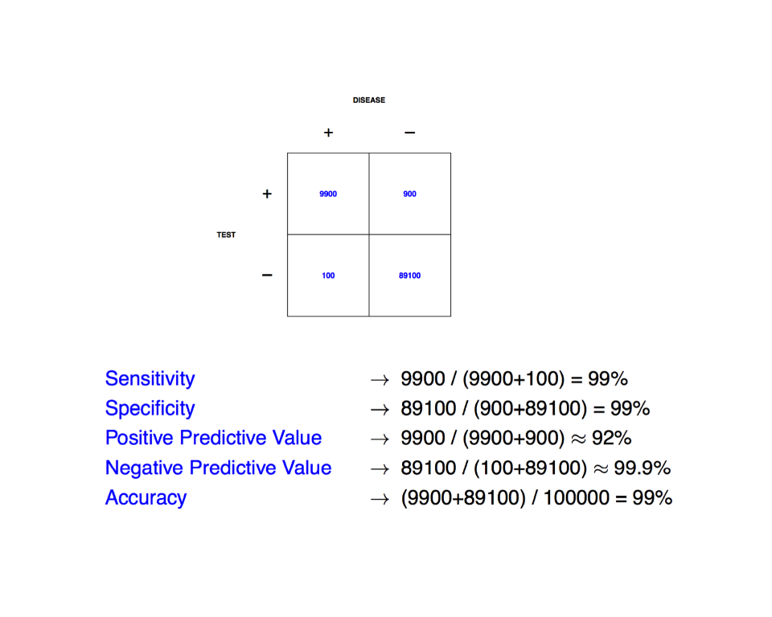

### Notable Measurements for Error – Continuous Variables

- **Mean squared error (MSE)** =
  $$\frac{1}{n} \sum_{i=1}^n (Prediction_i - Truth_i)^2$$
- **Root mean squared error (RMSE)** -
  $$\sqrt{\frac{1}{n} \sum_{i=1}^n(Prediction_i - Truth_i)^2}$$
  - in the same units as variable
  - most commonly used error measure for continuous data
  - is not an effective measures when there are outliers
    - one large value may significantly raise the RMSE
- **median absolute deviation** =
  $$median(|Prediction_i - Truth_i|)$$

$\pagebreak$

## Receiver Operating Characteristic Curves

- are commonly used techniques to measure the quality of a prediction algorithm.
- predictions for binary classification often are quantitative (i.e. probability, scale of 1 to 10)
  - different cutoffs/threshold of classification (> 0.8 $\rightarrow$ one outcome) yield different results/predictions
  - **Receiver Operating Characteristic** curves are generated to compare the different outcomes

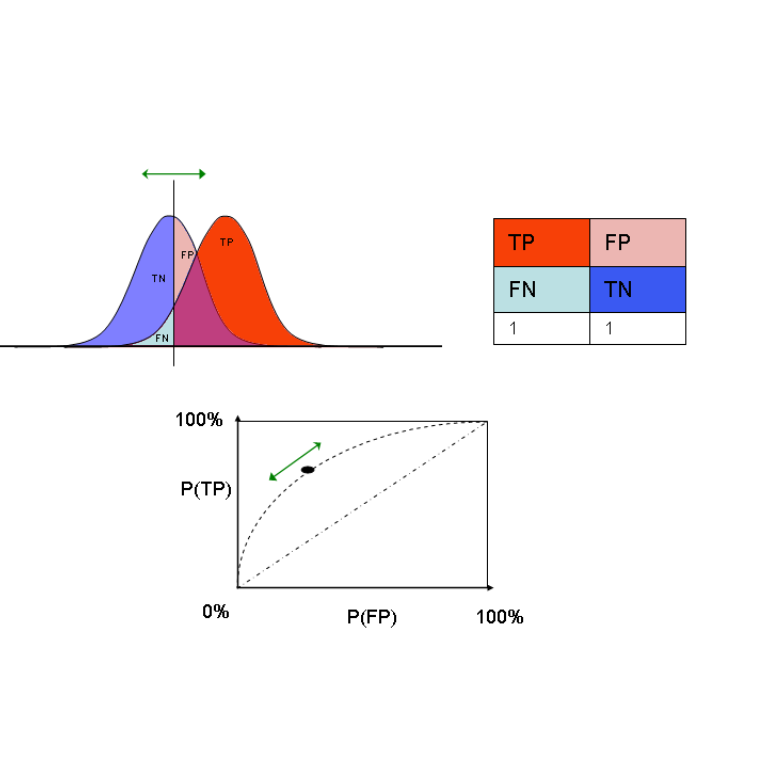

- ROC Curves
  - *x-axis* = 1 - specificity (or, probability of false positive)
  - *y-axis* = sensitivity (or, probability of true positive)
  - *points plotted* = cutoff/combination
  - *areas under curve* = quantifies whether the prediction model is viable or not
    - higher area $\rightarrow$ better predictor
    - area = 0.5 $\rightarrow$ effectively random guessing (diagonal line in the ROC curve)
    - area = 1 $\rightarrow$ perfect classifier
    - area = 0.8 $\rightarrow$ considered good for a prediction algorithm

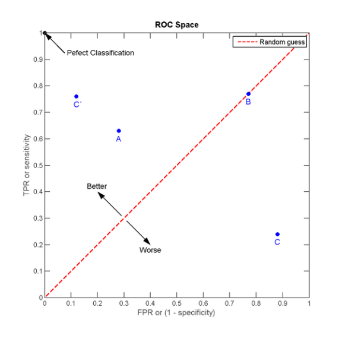

- *example*
  - each point on the graph corresponds with a specificity and sensitivity

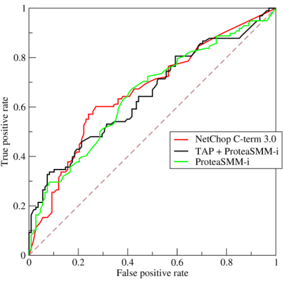

$\pagebreak$

## Cross Validation

- **procedures**
  1. split training set into sub-training/test sets
  2. build model on sub-training set
  3. evaluate on sub-test set
  4. repeat and average estimated errors
- **result**
  - we are able to fit/test various different models with different variables included to the find the best one on the cross-validated test sets
  - we are able to test out different types of prediction algorithms to use and pick the best performing one
  - we are able to choose the parameters in prediction function and estimate their values
  - **Note**: original test set completely untouched, so when final prediction algorithm is applied, the result will be an unbiased measurement of the **out of sample accuracy** of the model
- **approaches**
  - random subsampling
  - K-fold
  - leave one out
- **considerations**
  - for time series data data must be used in “chunks”
    - one time period might depending all time periods previously (should not take random samples)
  - if you cross-validate to pick predictors, the out of sample error rate may not be the most accurate and thus the errors should still be measured on independent data

### Random Subsampling

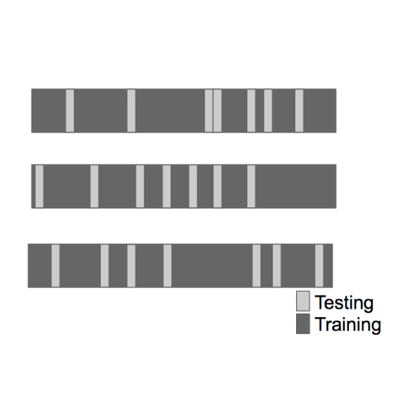

- a randomly sampled test set is subsetted out from the original training set
- the predictor is built on the remaining training data and applied to the test set
- the above are *three* random subsamplings from the same training set
- *considerations*
  - must be done *without replacement*
  - random sampling with replacement = *bootstrap*
    - underestimates of the error, since the if we get one right and the sample appears more than once we’ll get the other right
    - can be corrected with the ([0.632 Bootstrap](http://www.jstor.org/discover/10.2307/2965703?uid=2&uid=4&sid=21103054448997)), but it is complicated

### K-Fold

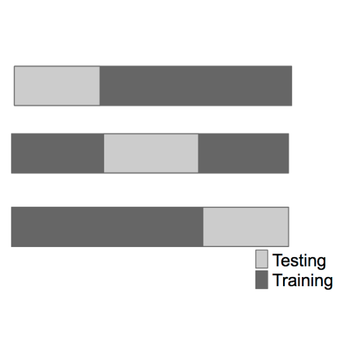

- break training set into $K$ subsets (above is a 3-fold cross validation)
- build the model/predictor on the remaining training data in each subset and applied to the test subset
- rebuild the data $K$ times with the training and test subsets and average the findings
- *considerations*
  - larger k = less bias, more variance
  - smaller k = more bias, less variance

### Leave One Out

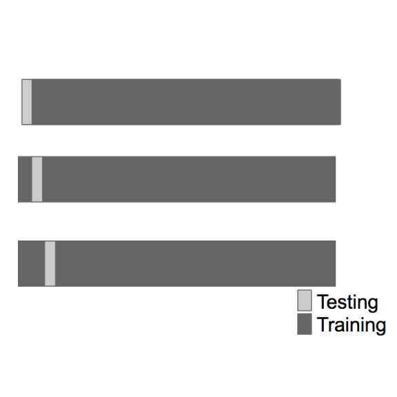

- leave out exactly one sample and build predictor on the rest of training data
- predict value for the left out sample
- repeat for each sample

$\pagebreak$

## `caret` Package ([tutorial](http://www.edii.uclm.es/~useR-2013/Tutorials/kuhn/user_caret_2up.pdf))

- **core functionality**
  - preprocessing/cleaning data $\rightarrow$ `preProcess()`
  - cross validation/data splitting $\rightarrow$ `createDataPartition()`, `createResample()`, `createTimeSlices()`
  - train algorithms on training data and apply to test sets $\rightarrow$ `train()`, `predict()`
  - model comparison (evaluate the accuracy of model on new data) $\rightarrow$ `confusionMatrix()`
- machine learning algorithms in `caret` package
  - linear discriminant analysis
  - regression
  - naive Bayes
  - support vector machines
  - classification and regression trees
  - random forests
  - boosting
  - many others
- `caret` provides uniform framework to build/predict using different models
  - create objects of different classes for different algorithms, and `caret` package allows algorithms to be run the same way through `predict()` function

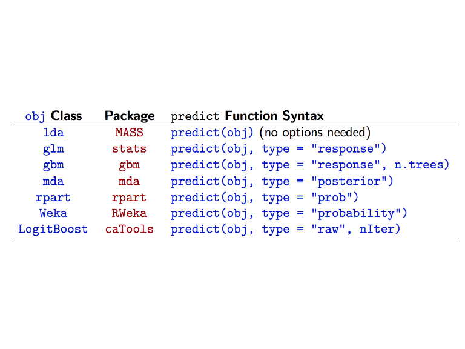

### Data Slicing

- `createDataPartition(y=data$var, times=1, p=0.75, list=FALSE)` $\rightarrow$ creates data partitions using given variable
  - `y=data$var` = specifies what outcome/variable to split the data on
  - `times=1` = specifies number of partitions to create (number of data splitting performed)
  - `p=0.75` = percent of data that will be for training the model
  - `list=FALSE` = returns a matrix of indices corresponding to **`p`%** of the data (training set)
    - **Note**: matrix is easier to subset the data with, so `list = FALSE` is generally what is used
    - `list=TRUE` = returns a list of indices corresponding to **`p`%** of the data (training set)
  - the function effectively returns a list of indexes of the training set which can then be leveraged to subset the data
    - `training<-data[inTrain, ]` = subsets the data to training set only
    - `testing<-data[-inTrain, ]` = the rest of the data set can then be stored as the test set
  - *example*

```r
# load packages and data
library(caret)
# create training set indexes with 75% of data
inTrain <- createDataPartition(y=spam$type,p=0.75, list=FALSE)
# subset spam data to training
training <- spam[inTrain,]
# subset spam data (the rest) to test
testing <- spam[-inTrain,]
# dimension of original and training dataset
rbind("original dataset" = dim(spam),"training set" = dim(training))
```

```
##                  [,1] [,2]
## original dataset 4601   58
## training set     3451   58
```

```r
# create 10 folds for cross validation and return the training set indices
folds <- createFolds(y=spam$type,k=10,list=TRUE,returnTrain=TRUE)
# structure of the training set indices
str(folds)
```

```
## List of 10
##  $ Fold01: int [1:4141] 1 2 3 4 5 6 7 8 9 10 ...
##  $ Fold02: int [1:4141] 1 2 3 5 6 7 8 9 11 12 ...
##  $ Fold03: int [1:4140] 1 2 3 4 6 7 8 9 10 11 ...
##  $ Fold04: int [1:4141] 2 3 4 5 6 7 8 9 10 11 ...
##  $ Fold05: int [1:4140] 1 2 3 4 5 6 7 8 9 10 ...
##  $ Fold06: int [1:4141] 1 2 3 4 5 6 7 8 9 10 ...
##  $ Fold07: int [1:4141] 1 2 3 4 5 6 7 8 10 11 ...
##  $ Fold08: int [1:4142] 1 2 3 4 5 7 8 9 10 11 ...
##  $ Fold09: int [1:4141] 1 2 3 4 5 6 7 8 9 10 ...
##  $ Fold10: int [1:4141] 1 4 5 6 9 10 11 13 14 15 ...
```

```r
# return the test set indices instead
# note: returnTrain = FALSE is unnecessary as it is the default behavior
folds.test <- createFolds(y=spam$type,k=10,list=TRUE,returnTrain=FALSE)
str(folds.test)
```

```
## List of 10
##  $ Fold01: int [1:460] 14 21 27 34 39 44 91 101 117 156 ...
##  $ Fold02: int [1:461] 15 17 61 67 74 80 81 102 122 123 ...
##  $ Fold03: int [1:460] 2 40 54 57 66 79 89 99 116 143 ...
##  $ Fold04: int [1:460] 13 18 65 68 69 84 87 92 104 111 ...
##  $ Fold05: int [1:460] 4 5 9 16 20 24 64 70 82 90 ...
##  $ Fold06: int [1:460] 7 25 38 51 55 56 115 138 147 152 ...
##  $ Fold07: int [1:459] 6 12 26 28 31 32 37 50 53 75 ...
##  $ Fold08: int [1:460] 1 3 22 30 33 45 48 49 62 72 ...
##  $ Fold09: int [1:460] 8 11 29 35 36 42 43 46 47 52 ...
##  $ Fold10: int [1:461] 10 19 23 41 60 63 71 83 85 97 ...
```

```r
# return first 10 elements of the first training set
folds[[1]][1:10]
```

```
##  [1]  1  2  3  4  5  6  7  8  9 10
```

- `createResample(y=data$var, times=10, list=TRUE)` = create 10 resamplings from the given data with replacement
  - `list=TRUE` = returns list of n vectors that contain indices of the sample
    - **Note**: each of the vectors is of length of the data, and contains indices
  - `times=10` = number of samples to create

```r
# create 10 resamples
resamples <- createResample(y=spam$type,times=10,list=TRUE)
# structure of the resamples (note some samples are repeated)
str(resamples)
```

```
## List of 10
##  $ Resample01: int [1:4601] 1 4 4 4 7 8 12 13 13 14 ...
##  $ Resample02: int [1:4601] 3 3 5 7 10 12 12 13 13 14 ...
##  $ Resample03: int [1:4601] 1 2 2 3 4 5 8 10 11 12 ...
##  $ Resample04: int [1:4601] 1 3 3 4 7 8 8 9 10 14 ...
##  $ Resample05: int [1:4601] 2 4 5 6 7 7 8 8 9 12 ...
##  $ Resample06: int [1:4601] 3 6 6 7 8 9 12 13 13 14 ...
##  $ Resample07: int [1:4601] 1 2 2 5 5 6 7 8 9 10 ...
##  $ Resample08: int [1:4601] 2 2 3 4 4 7 7 8 8 9 ...
##  $ Resample09: int [1:4601] 1 4 7 8 8 9 12 13 15 15 ...
##  $ Resample10: int [1:4601] 1 3 4 4 7 7 9 9 10 11 ...
```

- `createTimeSlices(y=data, initialWindow=20, horizon=10)` = creates training sets with specified window length and the corresponding test sets
  - `initialWindow=20` = number of consecutive values in each time slice/training set (i.e. values 1 - 20)
  - `horizon=10` = number of consecutive values in each predict/test set (i.e. values 21 - 30)
  - `fixedWindow=FALSE` = training sets always start at the first observation
    - this means that the first training set would be 1 - 20, the second will be 1 - 21, third 1 - 22, etc.
    - but the test sets are still like before (21 - 30, 22 - 31, etc.)

```r
# create time series data
tme <- 1:1000
# create time slices
folds <- createTimeSlices(y=tme,initialWindow=20,horizon=10)
# name of lists
names(folds)
```

```
## [1] "train" "test"
```

```r
# first training set
folds$train[[1]]
```

```
##  [1]  1  2  3  4  5  6  7  8  9 10 11 12 13 14 15 16 17 18 19 20
```

```r
# first test set
folds$test[[1]]
```

```
##  [1] 21 22 23 24 25 26 27 28 29 30
```

### Training Options ([tutorial](http://topepo.github.io/caret/training.html))

- `train(y ~ x, data=df, method="glm")` = function to apply the machine learning algorithm to construct model from training data

```r
# returns the arguments of the default train function
args(train.default)
```

```
## function (x, y, method = "rf", preProcess = NULL, ..., weights = NULL,
##     metric = ifelse(is.factor(y), "Accuracy", "RMSE"), maximize = ifelse(metric %in%
##         c("RMSE", "logLoss"), FALSE, TRUE), trControl = trainControl(),
##     tuneGrid = NULL, tuneLength = 3)
## NULL
```

- `train` function has a large set of parameters, below are the default options
  - `method="rf"` = default algorithm is random forest for training a given data set; `caret` contains a large number of algorithms
    - `names(getModelInfo())` = returns all the options for `method` argument
    - list of models and their information can be found [here](http://topepo.github.io/caret/modelList.html)
  - `preProcess=NULL` = set preprocess options (see *Preprocessing*)
  - `weights=NULL` = can be used to add weights to observations, useful for unbalanced distribution (a lot more of one type than another)
  - `metric=ifelse(is.factor(y), "Accuracy", "RMSE")` = default metric for algorithm is *Accuracy* for factor variables, and *RMSE*, or root mean squared error, for continuous variables
    - *Kappa* = measure of concordance (see *Notable Measurements for Error – Binary Variables*)
    - *RSquared* can also be used here as a metric, which represents R<sup>2</sup> from regression models (only useful for linear models)
  - `maximize=ifelse(metric=="RMSE", FALSE, TRUE)` = the algorithm should maximize *accuracy* and minimize *RMSE*
  - `trControl=trainControl()` = training controls for the model, more details below
  - `tuneGrid=NULL`
  - `tuneLength=3`

```r
# returns the default arguments for the trainControl object
args(trainControl)
```

```
## function (method = "boot", number = ifelse(grepl("cv", method),
##     10, 25), repeats = ifelse(grepl("cv", method), 1, number),
##     p = 0.75, search = "grid", initialWindow = NULL, horizon = 1,
##     fixedWindow = TRUE, verboseIter = FALSE, returnData = TRUE,
##     returnResamp = "final", savePredictions = FALSE, classProbs = FALSE,
##     summaryFunction = defaultSummary, selectionFunction = "best",
##     preProcOptions = list(thresh = 0.95, ICAcomp = 3, k = 5),
##     sampling = NULL, index = NULL, indexOut = NULL, timingSamps = 0,
##     predictionBounds = rep(FALSE, 2), seeds = NA, adaptive = list(min = 5,
##         alpha = 0.05, method = "gls", complete = TRUE), trim = FALSE,
##     allowParallel = TRUE)
## NULL
```

- `trainControl` creates an object that sets many options for how the model will be applied to the training data
  - **Note**: the default values are listed below but you can use them to set the parameters to your discretion
  - `method="boot"` =
    - `"boot"` = bootstrapping (drawing with replacement)
    - `"boot632"` = bootstrapping with adjustment
    - `"cv"` = cross validation
    - `"repeatedcv"` = repeated cross validation
    - `"LOOCV"` = leave one out cross validation
  - `number=ifelse(grepl("cv", method),10, 25)` = number of subsamples to take
    - `number=10` = default for any kind of cross validation
    - `number=25` = default for bootstrapping
    - **Note**: `number` should be increased when fine-tuning model with large number of parameter
  - `repeats=ifelse(grepl("cv", method), 1, number)` = numbers of times to repeat the subsampling
    - `repeats=1` = default for any cross validation method
    - `repeats=25` = default for bootstrapping
  - `p=0.75` = default percentage of data to create training sets
  - `initialWindow=NULL, horizon=1, fixedWindow=TRUE` = parameters for time series data
  - `verboseIter=FALSE` = print the training logs
  - `returnData=TRUE`, returnResamp = “final”,
  - `savePredictions=FALSE` = save the predictions for each resample
  - `classProbs=FALSE` = return classification probabilities along with the predictions
  - `summaryFunction=defaultSummary` = default summary of the model,
  - `preProcOptions=list(thresh = 0.95, ICAcomp = 3, k = 5)` = specifies preprocessing options for the model
  - `predictionBounds=rep(FALSE, 2)` = specify the range of the predicted value
    - for numeric predictions, `predictionBounds=c(10, NA)` would mean that any value lower than 10 would be treated as 10 and no upper bounds
  - `seeds=NA` = set the seed for the operation
    - **Note**: setting this is important when you want to reproduce the same results when the `train` function is run
  - `allowParallel=TRUE` = sets for parallel processing/computations

### Plotting Predictors ([tutorial](http://caret.r-forge.r-project.org/visualizations.html))

- it is important to only plot the data in the training set
  - using the test data may lead to over-fitting (model should not be adjusted to test set)
- goal of producing these exploratory plots = look for potential outliers, skewness, imbalances in outcome/predictors, and explainable groups of points/patterns
- `featurePlot(x=predictors, y=outcome, plot="pairs")` = short cut to plot the relationships between the predictors and outcomes

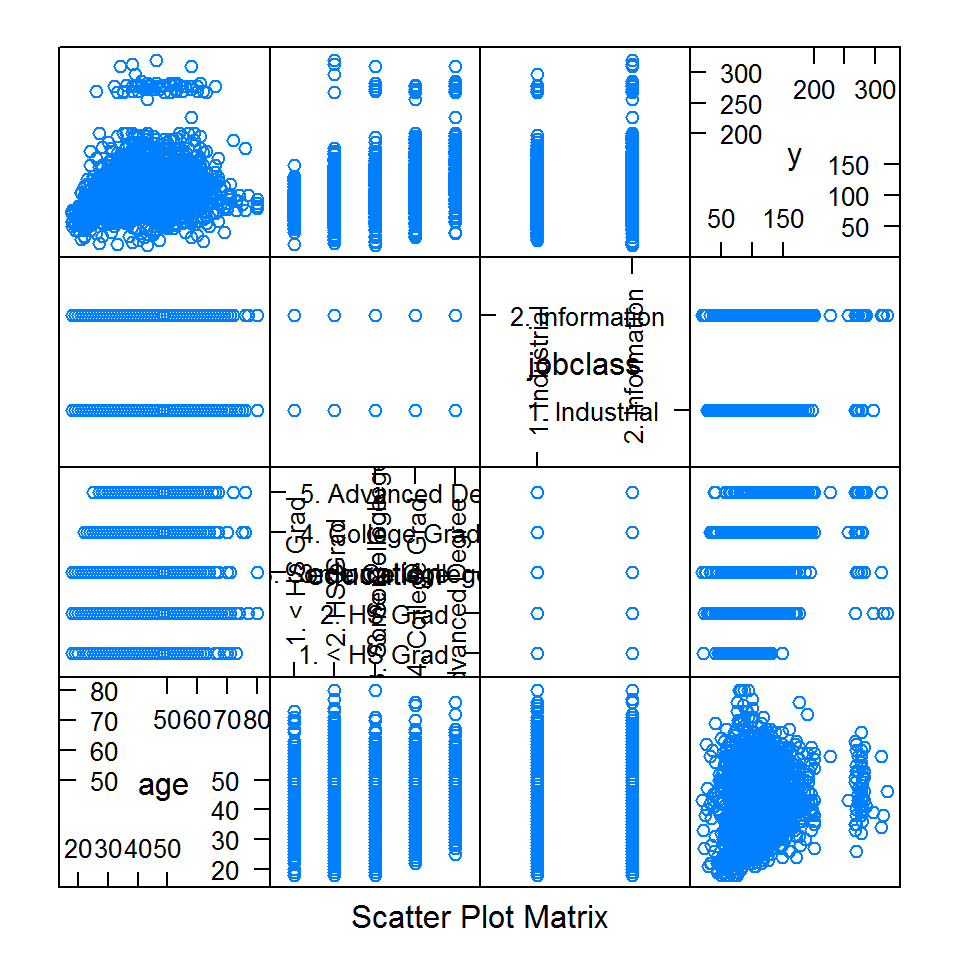

```r
# load relevant libraries
library(ISLR); library(ggplot2);
# load wage data
data(Wage)
# create training and test sets
inTrain <- createDataPartition(y=Wage$wage,p=0.7, list=FALSE)
training <- Wage[inTrain,]
testing <- Wage[-inTrain,]
# plot relationships between the predictors and outcome
featurePlot(x=training[,c("age","education","jobclass")], y = training$wage,plot="pairs")
```

- `qplot(age, wage, color=eduction, data=training)` = can be used to separate data by a factor variable (by coloring the points differently)
  - `geom_smooth(method = "lm")` = adds a regression line to the plots
  - `geom=c("boxplot", "jitter")` = specifies what kind of plot to produce, in this case both the boxplot and the point cloud

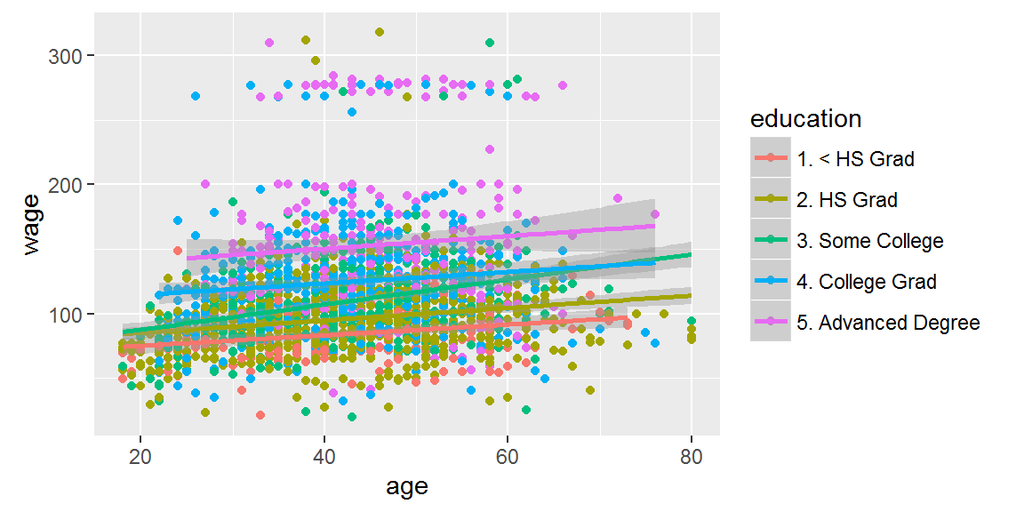

```r
# qplot plus linear regression lines
qplot(age,wage,colour=education,data=training)+geom_smooth(method='lm',formula=y~x)
```

- `cut2(variable, g=3)` = creates a new factor variable by cutting the specified variable into n groups (3 in this case) based on percentiles
  - **Note**: `cut2` function is part of the `Hmisc` package, so `library(Hmisc)` must be run first
  - this variable can then be used to tabulate/plot the data
- `grid.arrange(p1, p2, ncol=2)` = `ggplot2` function the print multiple graphs on the same plot
  - **Note**: `grid.arrange` function is part of the `gridExtra` package, so `library(gridExtra)` must be run first

```r
# load Hmisc and gridExtra packages
library(Hmisc);library(gridExtra);
```

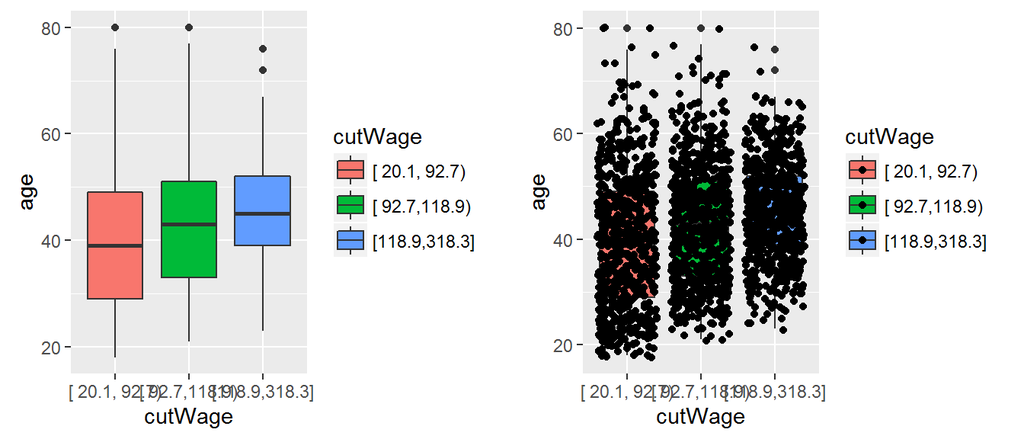

```r
# cute the wage variable
cutWage <- cut2(training$wage,g=3)
# plot the boxplot
p1 <- qplot(cutWage,age, data=training,fill=cutWage,
      geom=c("boxplot"))
# plot boxplot and point clusters
p2 <- qplot(cutWage,age, data=training,fill=cutWage,
      geom=c("boxplot","jitter"))
# plot the two graphs side by side
grid.arrange(p1,p2,ncol=2)
```

- `table(cutVariable, data$var2)` = tabulates the cut factor variable vs another variable in the dataset (ie; builds a contingency table using cross-classifying factors)
- `prop.table(table, margin=1)` = converts a table to a proportion table
  - `margin=1` = calculate the proportions based on the rows
  - `margin=2` = calculate the proportions based on the columns

```r
# tabulate the cutWage and jobclass variables
t <- table(cutWage,training$jobclass)
# print table
t
```

```
##
## cutWage         1. Industrial 2. Information
##   [ 20.1, 92.7)           446            256
##   [ 92.7,118.9)           380            338
##   [118.9,318.3]           279            403
```

```r
# convert to proportion table based on the rows
prop.table(t,1)
```

```
##
## cutWage         1. Industrial 2. Information
##   [ 20.1, 92.7)     0.6353276      0.3646724
##   [ 92.7,118.9)     0.5292479      0.4707521
##   [118.9,318.3]     0.4090909      0.5909091
```

- `qplot(var1, color=var2, data=training, geom="density")` = produces density plot for the given numeric and factor variables
  - effectively smoothed out histograms
  - provides for easy overlaying of groups of data
    - break different variables up by group and see how outcomes change between groups

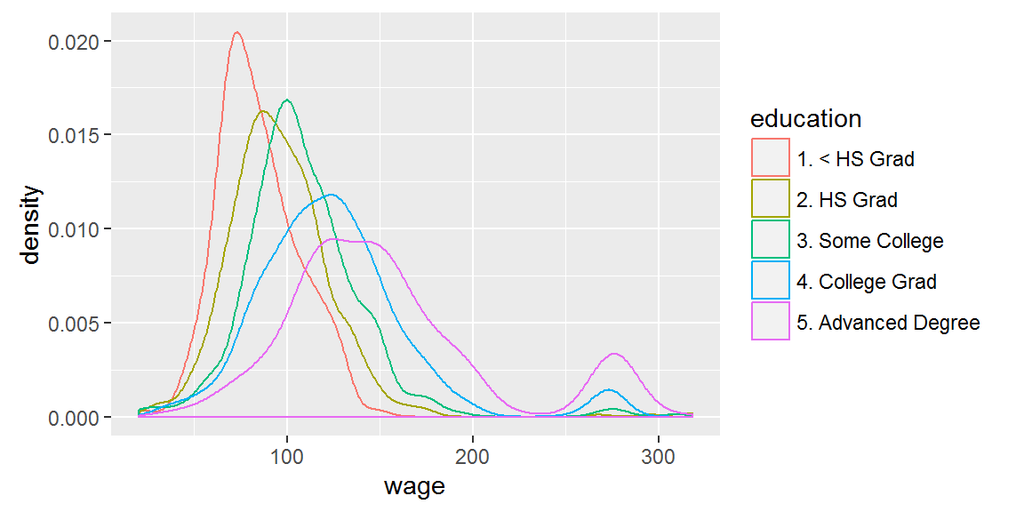

```r
# produce density plot
qplot(wage,colour=education,data=training,geom="density")
```

### Preprocessing ([tutorial](http://caret.r-forge.r-project.org/preprocess.html))

- some predictors may have strange distributions (i.e. skewed) and may need to be transformed to be more useful for prediction algorithm
  - particularly true for model based algorithms $\rightarrow$ naive Bayes, linear discriminate analysis, linear regression
- **centering** = subtracting the observations of a particular variable by its mean
- **scaling** = dividing the observations of a particular variable by its standard deviation
- **normalizing** = centering and scaling the variable $\rightarrow$ effectively converting each observation to the number of standard deviations away from the mean
  - the distribution of the normalized variable will have a mean of 0 and standard deviation of 1
  - **Note**: normalizing data can help remove bias and high variability, but may not be applicable in all cases
- **Note**: if a predictor/variable is standardized when training the model, the same transformations must be performed on the `test` set with the mean and standard deviation of the `train` variables
  - this means that the mean and standard deviation of the normalized test variable will *NOT* be 0 and 1, respectively, but will be close
  - transformations must likely be imperfect but test/train sets must be processed the same way
- `train(y~x, data=training, preProcess=c("center", "scale"))` = preprocessing can be directly specified in the `train` function
  - `preProcess=c("center", "scale")` = normalize all predictors before constructing model
- `preProcess(trainingData, method=c("center", "scale")` = function in the `caret` to standardize data
  - you can store the result of the `preProcess` function as an object and apply it to the `train` and `test` sets using the `predict` function

```r
# load spam data
data(spam)
# create train and test sets
inTrain <- createDataPartition(y=spam$type,p=0.75, list=FALSE)
training <- spam[inTrain,]
testing <- spam[-inTrain,]
# create preProcess object for all predictors ("-58" because 58th = outcome)
preObj <- preProcess(training[,-58],method=c("center","scale"))
# normalize training set
trainCapAveS <- predict(preObj,training[,-58])$capitalAve
# normalize test set using training parameters
testCapAveS <- predict(preObj,testing[,-58])$capitalAve
# compare results for capitalAve variable
rbind(train = c(mean = mean(trainCapAveS), std = sd(trainCapAveS)),
    test = c(mean(testCapAveS), sd(testCapAveS)))
```

```
##               mean      std
## train 4.542268e-18 1.000000
## test  5.224576e-02 1.475022
```

- `preprocess(data, method="BoxCox")` = applies BoxCox transformations to continuous data to help normalize the variables through maximum likelihood
  - **Note**: note it assumes continuous values and DOES NOT deal with repeated values
  - `qqnorm(processedVar)` = can be used to produce the Q-Q plot which compares the theoretical quantiles with the sample quantiles to see the normality of the data

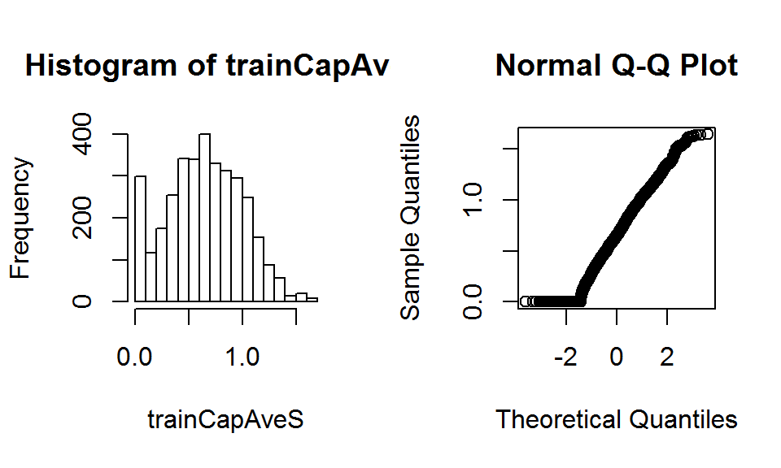

```r
# set up BoxCox transforms
preObj <- preProcess(training[,-58],method=c("BoxCox"))
# perform preprocessing on training data
trainCapAveS <- predict(preObj,training[,-58])$capitalAve
# plot histogram and QQ Plot
# Note: the transformation definitely helped to
# normalize the data but it does not produce perfect result
par(mfrow=c(1,2)); hist(trainCapAveS); qqnorm(trainCapAveS)
```

- `preProcess(data, method="knnImpute")` = impute/estimate the missing data using **k nearest neighbors (knn)** imputation
  - `knnImpute` = takes the k nearest neighbors from the missing value and averages the value to impute the missing observations
  - **Note**: most prediction algorithms are not build to handle missing data

```r
# Make some values NA
training$capAve <- training$capitalAve
selectNA <- rbinom(dim(training)[1],size=1,prob=0.05)==1
training$capAve[selectNA] <- NA
# Impute and standardize
preObj <- preProcess(training[,-58],method="knnImpute")
capAve <- predict(preObj,training[,-58])$capAve
# Standardize true values
capAveTruth <- training$capitalAve
capAveTruth <- (capAveTruth-mean(capAveTruth))/sd(capAveTruth)
# compute differences between imputed values and true values
quantile(capAve - capAveTruth)
```

```
##            0%           25%           50%           75%          100%
## -1.5812925177 -0.0008484844  0.0004010159  0.0009975194  0.2620668318
```

$\pagebreak$

## Covariate Creation/Feature Extraction

- **[level 1]**: construct covariate (usable metric, feature) from raw data depends heavily on application
  - ideally we want to summarize data without too much information loss
  - examples
    - *text files*: frequency of words, frequency of phrases ([Google ngrams](https://books.google.com/ngrams)), frequency of capital letters
    - *images*: edges, corners, blobs, ridges (computer vision feature detection)
    - *webpages*: number and type of images, position of elements, colors, videos ([A/B Testing](http://en.wikipedia.org/wiki/A/B_testing))
    - *people*: height, weight, hair color, sex, country of origin
  - generally, more knowledge and understanding you have of the system/data, the easier it will be to extract the summarizing features
    - when in doubt, more features is always safer $\rightarrow$ lose less information and the features can be filtered during model construction
  - this process can be automated (i.e. PCA) but generally have to be very careful, as one very useful feature in the training data set may not have as much effect on the test data set
  - **Note**: science is the key here, Google “feature extraction for [data type]” for more guidance
    - the goal is always to find the salient characteristics that are likely to be different from observation to observation
- **[level 2]**: construct new covariates from extracted covariate
  - generally transformations of features you extract from raw data
  - used more for methods like regression and support vector machines (SVM), whose accuracy depend more on the distribution of input variables
  - models like classification trees don’t require as many complex covariates
  - best approach is through exploratory analysis (tables/plots)
  - should only be performed on the train dataset
  - new covariates should be added to data frames under recognizable names so they can be used later
  - `preProcess()` can be leveraged to handle creating new covariates
  - **Note**: always be careful about over-fitting

### Creating Dummy Variables

- convert factor variables to indicator/dummy variable $\rightarrow$ qualitative become quantitative
- `dummyVars(outcome~var, data=training)` = creates a dummy variable object that can be used through `predict` function to create dummy variables
  - `predict(dummyObj, newdata=training)` = creates appropriate columns to represent the factor variable with appropriate 0s and 1s
    - 2 factor variable $\rightarrow$ two columns which have 0 or 1 depending on the outcome
    - 3 factor variable $\rightarrow$ three columns which have 0, 0, and 1 representing the outcome
    - **Note**: only one of the columns can have values of 1 for each observation

```r
# setting up data
inTrain <- createDataPartition(y=Wage$wage,p=0.7, list=FALSE)
training <- Wage[inTrain,]; testing <- Wage[-inTrain,]
# create a dummy variable object
dummies <- dummyVars(wage ~ jobclass,data=training)
# create the dummy variable columns
head(predict(dummies,newdata=training))
```

```
##        jobclass.1. Industrial jobclass.2. Information
## 231655                      1                       0
## 86582                       0                       1
## 161300                      1                       0
## 155159                      0                       1
## 11443                       0                       1
## 376662                      0                       1
```

### Removing Zero Covariates

- some variables have no variability at all (i.e. variable indicating if an email contained letters)
- these variables are not useful when we want to construct a prediction model
- `nearZeroVar(training, saveMetrics=TRUE)` = returns list of variables in training data set with information on frequency ratios, percent uniques, whether or not it has zero variance
  - `freqRatio` = ratio of frequencies for the most common value over second most common value
  - `percentUnique` = percentage of unique data points out of total number of data points
  - `zeroVar` = TRUE/FALSE indicating whether the predictor has only one distinct value
  - `nzv` = TRUE/FALSE indicating whether the predictor is a near zero variance predictor
  - **Note**: when `nzv` = TRUE, those variables should be thrown out

```r
# print nearZeroVar table
nearZeroVar(training,saveMetrics=TRUE)
```

```
##            freqRatio percentUnique zeroVar   nzv
## year        1.040816    0.33301618   FALSE FALSE
## age         1.257143    2.85442436   FALSE FALSE
## sex         0.000000    0.04757374    TRUE  TRUE
## maritl      3.161220    0.23786870   FALSE FALSE
## race        8.046512    0.19029496   FALSE FALSE
## education   1.436975    0.23786870   FALSE FALSE
## region      0.000000    0.04757374    TRUE  TRUE
## jobclass    1.108325    0.09514748   FALSE FALSE
## health      2.468647    0.09514748   FALSE FALSE
## health_ins  2.294671    0.09514748   FALSE FALSE
## logwage     1.025316   18.79162702   FALSE FALSE
## wage        1.025316   18.79162702   FALSE FALSE
```

### Creating Splines (Polynomial Functions)

- when you want to fit curves through the data, basis functions can be leveraged
- [`splines` package] `bs(data$var, df=3)` = creates 3 new columns corresponding to the var, var<sup>2</sup>, and var<sup>3</sup> terms
- `ns()` and `poly()` can also be used to generate polynomials
- `gam()` function can also be used and it allows for smoothing of multiple variables with different values for each variable
- **Note**: the same polynomial operations must be performed on the test sets using the `predict` function

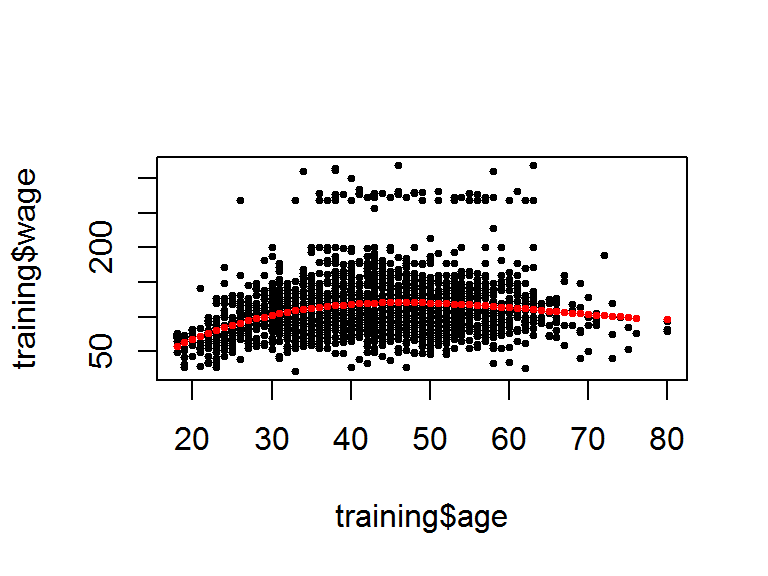

```r
# load splines package
library(splines)
# create polynomial function
bsBasis <- bs(training$age,df=3)
# fit the outcome on the three polynomial terms
lm1 <- lm(wage ~ bsBasis,data=training)
# plot all age vs wage data
plot(training$age,training$wage,pch=19,cex=0.5)
# plot the fitted polynomial function
points(training$age,predict(lm1,newdata=training),col="red",pch=19,cex=0.5)
```

```r
# predict on test values
head(predict(bsBasis,age=testing$age))
```

```
##              1          2           3
## [1,] 0.0000000 0.00000000 0.000000000
## [2,] 0.2368501 0.02537679 0.000906314
## [3,] 0.4163380 0.32117502 0.082587862
## [4,] 0.4308138 0.29109043 0.065560908
## [5,] 0.3625256 0.38669397 0.137491189
## [6,] 0.3063341 0.42415495 0.195763821
```

### Multicore Parallel Processing

- many of the algorithms in the `caret` package are computationally intensive
- since most of the modern machines have multiple cores on their CPUs, it is often wise to enable *multicore parallel processing* to expedite the computations
- `doMC` package is recommended to be used for `caret` computations ([reference](http://topepo.github.io/caret/parallel.html))
  - `doMC::registerDoMC(cores=4)` = registers 4 cores for R to utilize
  - the number of cores you should specify depends on the CPU on your computer (system information usually contains the number of cores)
    - it’s also possible to find the number of cores by directly searching for your CPU model number on the Internet
  - **Note**: once registered, you should see in your task manager/activity monitor that 4 “R Session” appear when you run your code

$\pagebreak$

## Preprocessing with Principal Component Analysis (PCA)

- constructing a prediction model may not require every predictor
- ideally we want to capture the *most variation* with the *least* amount of variables
  - weighted combination of predictors may improve fit
  - combination needs to capture the *most information*
- PCA is suited to do this and will help reduce number of predictors as well as reduce noise (due to averaging)
  - statistical goal = find new set of multivariate variables that are *uncorrelated* and explain as much variance as possible
  - data compression goal = find the best matrix created with fewer variables that explains the original data
  - PCA is most useful for linear-type models (GLM, LDA)
  - generally more difficult to interpret the predictors (complex weighted sums of variables)
  - **Note**: outliers are can be detrimental to PCA as they may represent a lot of variation in data
    - exploratory analysis (plots/tables) should be used to identify problems with the predictors
    - transformations with log/BoxCox may be helpful

### `prcomp` Function

- `pr<-prcomp(data)` = performs PCA on all variables and returns a `prcomp` object that contains information about standard deviations and rotations
  - `pr$rotations` = returns eigenvectors for the linear combinations of all variables (coefficients that variables are multiplied by to come up with the principal components) $\rightarrow$ how the principal components are created
  - often times, it is useful to take the `log` transformation of the variables and adding 1 before performing PCA
    - helps to reduce skewness or strange distribution in data
    - log(0) = - infinity, so we add 1 to account for zero values
    - makes data more Gaussian
  - `plot(pr)` = plots the percent variation explained by the first 10 principal components (PC)
    - can be used to find the PCs that represent the most variation

```r
# load  spam data
data(spam)
# perform PCA on dataset
prComp <- prcomp(log10(spam[,-58]+1))
# print out the eigenvector/rotations first 5 rows and PCs
head(prComp$rotation[, 1:5], 5)
```

```
##                 PC1           PC2         PC3         PC4          PC5
## make    0.019370409  0.0427855959 -0.01631961  0.02798232 -0.014903314
## address 0.010827343  0.0408943785  0.07074906 -0.01407049  0.037237531
## all     0.040923168  0.0825569578 -0.03603222  0.04563653  0.001222215
## num3d   0.006486834 -0.0001333549  0.01234374 -0.01005991 -0.001282330
## our     0.036963221  0.0941456085 -0.01871090  0.05098463 -0.010582039
```

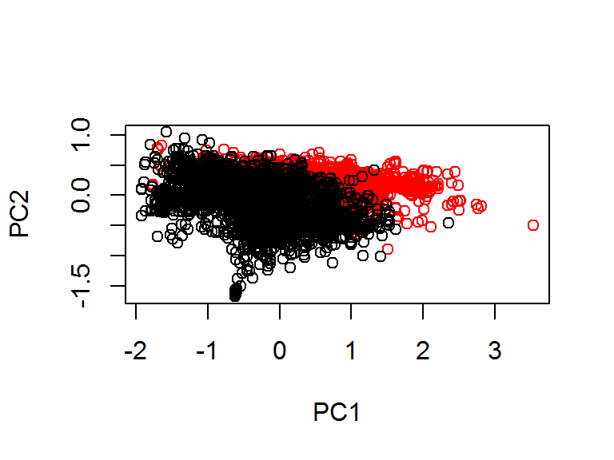

```r
# create new variable that marks spam as 2 and nospam as 1
typeColor <- ((spam$type=="spam")*1 + 1)
# plot the first two principal components
plot(prComp$x[,1],prComp$x[,2],col=typeColor,xlab="PC1",ylab="PC2")
```

### `caret` Package

- `pp<-preProcess(log10(training[,-58]+1),method="pca",pcaComp=2,thresh=0.8))` = perform PCA with `preProcess` function and returns the number of principal components that can capture the majority of the variation
  - creates a `preProcess` object that can be applied using `predict` function
  - `pcaComp=2` = specifies the number of principal components to compute (2 in this case)
  - `thresh=0.8` = threshold for variation captured by principal components
    - `thresh=0.95` = default value, which returns the number of principal components that are needed to capture 95% of the variation in data
- `predict(pp, training)` = computes new variables for the PCs (2 in this case) for the training data set
  - the results from `predict` can then be used as data for the prediction model
  - **Note**: the same PCA must be performed on the test set

```r
# create train and test sets
inTrain <- createDataPartition(y=spam$type,p=0.75, list=FALSE)
training <- spam[inTrain,]
testing <- spam[-inTrain,]
# create preprocess object
preProc <- preProcess(log10(training[,-58]+1),method="pca",pcaComp=2)
# calculate PCs for training data
trainPC <- predict(preProc,log10(training[,-58]+1))
# run model on outcome and principle components
modelFit <- train(training$type ~ .,method="glm",data=trainPC)
# calculate PCs for test data
testPC <- predict(preProc,log10(testing[,-58]+1))
# compare results
confusionMatrix(testing$type,predict(modelFit,testPC))
```

```
## Confusion Matrix and Statistics
##
##           Reference
## Prediction nonspam spam
##    nonspam     660   37
##    spam         67  386
##
##                Accuracy : 0.9096
##                  95% CI : (0.8915, 0.9255)
##     No Information Rate : 0.6322
##     P-Value [Acc > NIR] : < 2e-16
##
##                   Kappa : 0.8084
##  Mcnemar's Test P-Value : 0.00446
##
##             Sensitivity : 0.9078
##             Specificity : 0.9125
##          Pos Pred Value : 0.9469
##          Neg Pred Value : 0.8521
##              Prevalence : 0.6322
##          Detection Rate : 0.5739
##    Detection Prevalence : 0.6061
##       Balanced Accuracy : 0.9102
##
##        'Positive' Class : nonspam
##
```

- alternatively, PCA can be directly performed with the `train` method
  - `train(outcome ~ ., method="glm", preProcess="pca", data=training)` = performs PCA first on the training set and then runs the specified model
    - effectively the same procedures as above (`preProcess` $\rightarrow$ `predict`)
- **Note**: in both cases, the PCs were able to achieve 90+% accuracy

```r
# construct model
modelFit <- train(training$type ~ .,method="glm",preProcess="pca",data=training)
# print results of model
confusionMatrix(testing$type,predict(modelFit,testing))
```

```
## Confusion Matrix and Statistics
##
##           Reference
## Prediction nonspam spam
##    nonspam     663   34
##    spam         55  398
##
##                Accuracy : 0.9226
##                  95% CI : (0.9056, 0.9374)
##     No Information Rate : 0.6243
##     P-Value [Acc > NIR] : < 2e-16
##
##                   Kappa : 0.8366
##  Mcnemar's Test P-Value : 0.03401
##
##             Sensitivity : 0.9234
##             Specificity : 0.9213
##          Pos Pred Value : 0.9512
##          Neg Pred Value : 0.8786
##              Prevalence : 0.6243
##          Detection Rate : 0.5765
##    Detection Prevalence : 0.6061
##       Balanced Accuracy : 0.9223
##
##        'Positive' Class : nonspam
##
```

$\pagebreak$

## Predicting with Regression

- **prediction with regression** = fitting regression model (line) to data $\rightarrow$ multiplying each variable by coefficients to predict outcome
- useful when the relationship between the variables can be modeled as linear
- the model is easy to implement and the coefficients are easy to interpret
- if the relationships are non-linear, the regression model may produce poor results/accuracy
  - **Note**: linear regressions are generally used in combination with other models
- **model**
  $$Y_i = \beta_0 + \beta_1 X_{1i} + \beta_2 X_{2i} + \ldots + \beta_p X_{pi} + e_i$$
  - where $\beta_0$ is the intercept (when all variables are 0)
  - $\beta_1, \beta_2, \ldots, \beta_p$ are the coefficients
  - $X_{1i}, X_{2i}, \ldots, X_{pi}$ are the variables/covariates
  - $e_i$ is the error
  - $Y_i$ is the outcome
- **prediction**
  $$\hat Y_i = \hat \beta_0 + \hat \beta_1 X_{1i} + \hat \beta_2 X_{2i} + \ldots + \hat \beta_p X_{pi}$$
  - where $\hat \beta_0$ is the estimated intercept (when all variables are 0)
  - $\hat \beta_1, \hat \beta_2, \ldots, \hat \beta_p$ are the estimated coefficients
  - $X_{1i}, X_{2i}, \ldots, X_{pi}$ are the variables/covariates
  - $\hat Y_i$ is the *predicted outcome*

### R Commands and Examples

- `lm<-lm(y ~ x, data=train)` = runs a linear model of outcome y on predictor x $\rightarrow$ univariate regression
  - `summary(lm)` = returns summary of the linear regression model, which will include coefficients, standard errors, $t$ statistics, and p values
  - `lm(y ~ x1+x2+x3, data=train)` = run linear model of outcome y on predictors x1, x2, and x3
  - `lm(y ~ ., data=train` = run linear model of outcome y on all predictors
- `predict(lm, newdata=df)` = use the constructed linear model to predict outcomes ($\hat Y_i$) for the new values
  - `newdata` data frame must have the same variables (factors must have the same levels) as the training data
  - `newdata=test` = predict outcomes for the test set based on linear regression model from the training
  - **Note**: the regression line will not be a perfect fit on the test set since it was constructed on the training set
- RSME can be calculated to measure the accuracy of the linear model
  - **Note**: $RSME_{test}$, which estimates the out-of-sample error, is almost always **GREATER** than $RSME_{train}$

```r
# load data
data(faithful)
# create train and test sets
inTrain <- createDataPartition(y=faithful$waiting, p=0.5, list=FALSE)
trainFaith <- faithful[inTrain,]; testFaith <- faithful[-inTrain,]
# build linear model
lm1 <- lm(eruptions ~ waiting,data=trainFaith)
# print summary of linear model
summary(lm1)
```

```
##
## Call:
## lm(formula = eruptions ~ waiting, data = trainFaith)
##
## Residuals:
##      Min       1Q   Median       3Q      Max
## -1.21459 -0.32888  0.03173  0.32989  1.02253
##
## Coefficients:
##              Estimate Std. Error t value Pr(>|t|)
## (Intercept) -1.730348   0.215717  -8.021 4.46e-13 ***
## waiting      0.074080   0.002984  24.826  < 2e-16 ***
## ---
## Signif. codes:  0 '***' 0.001 '**' 0.01 '*' 0.05 '.' 0.1 ' ' 1
##
## Residual standard error: 0.4868 on 135 degrees of freedom
## Multiple R-squared:  0.8203, Adjusted R-squared:  0.819
## F-statistic: 616.3 on 1 and 135 DF,  p-value: < 2.2e-16
```

```r
# predict eruptions for new waiting time
newdata <- data.frame(waiting=80)
predict(lm1,newdata)
```

```
##        1
## 4.196029
```

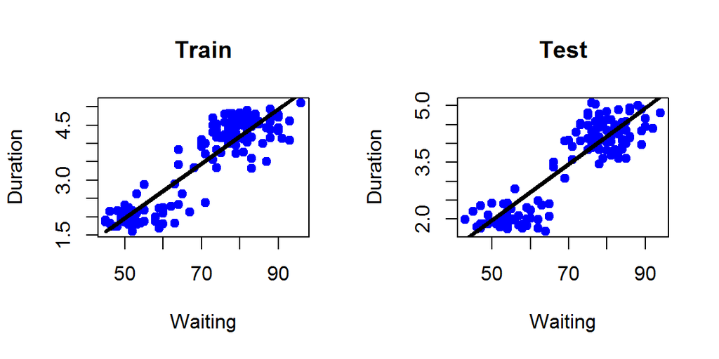

```r
# create 1 x 2 panel plot
par(mfrow=c(1,2))
# plot train data with the regression line
plot(trainFaith$waiting,trainFaith$eruptions,pch=19,col="blue",xlab="Waiting",
    ylab="Duration", main = "Train")
lines(trainFaith$waiting,predict(lm1),lwd=3)
# plot test data with the regression line
plot(testFaith$waiting,testFaith$eruptions,pch=19,col="blue",xlab="Waiting",
    ylab="Duration", main = "Test")
lines(testFaith$waiting,predict(lm1,newdata=testFaith),lwd=3)
```

```r
# Calculate RMSE on training and test sets
c(trainRMSE = sqrt(sum((lm1$fitted-trainFaith$eruptions)^2)),
    testRMSE = sqrt(sum((predict(lm1,newdata=testFaith)-testFaith$eruptions)^2)))
```

```
## trainRMSE  testRMSE
##  5.656642  5.915815
```

- `pi<-predict(lm, newdata=test, interval="prediction")` = returns 3 columns for `fit` (predicted value, same as before), `lwr` (lower bound of prediction interval), and `upr` (upper bound of prediction interval)
  - `matlines(x, pi, type="l")` = plots three lines, one for the linear fit and two for upper/lower prediction interval bounds

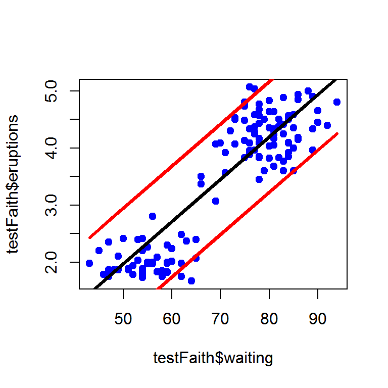

```r
# calculate prediction interval
pred1 <- predict(lm1,newdata=testFaith,interval="prediction")
# plot data points (eruptions, waiting)
plot(testFaith$waiting,testFaith$eruptions,pch=19,col="blue")
# plot fit line and prediction interval
matlines(testFaith$waiting,pred1,type="l",,col=c(1,2,2),lty = c(1,1,1), lwd=3)
```

- `lm <- train(y ~ x, method="lm", data=train)` = run linear model on the training data $\rightarrow$ identical to `lm` function
  - `summary(lm$finalModel)` = returns summary of the linear regression model, which will include coefficients, standard errors, $t$ statistics, and p values $\rightarrow$ identical to `summary(lm)` for a `lm` object
  - `train(y ~ ., method="lm", data=train)` = run linear model on all predictors in training data
    - multiple predictors (dummy/indicator variables) are created for factor variables
  - `plot(lm$finalModel)` = construct 4 diagnostic plots for evaluating the model
    - **Note**: more information on these plots can be found at `?plot.lm`
    - *Residuals vs Fitted*
    - *Normal Q-Q*
    - *Scale-Location*
    - *Residuals vs Leverage*

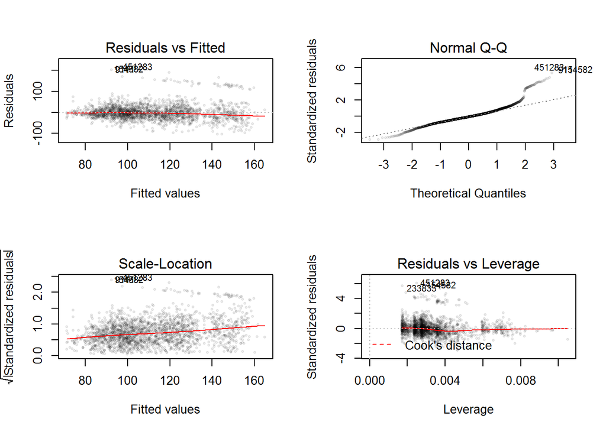

```r
# create train and test sets
inTrain <- createDataPartition(y=Wage$wage,p=0.7, list=FALSE)
training <- Wage[inTrain,]; testing <- Wage[-inTrain,]
# fit linear model for age jobclass and education
modFit<- train(wage ~ age + jobclass + education,method = "lm",data=training)
# store final model
finMod <- modFit$finalModel
# set up 2 x 2 panel plot
par(mfrow = c(2, 2))
# construct diagnostic plots for model
plot(finMod,pch=19,cex=0.5,col="#00000010")
```

- plotting residuals by fitted values and coloring with a variable not used in the model helps spot a trend in that variable.

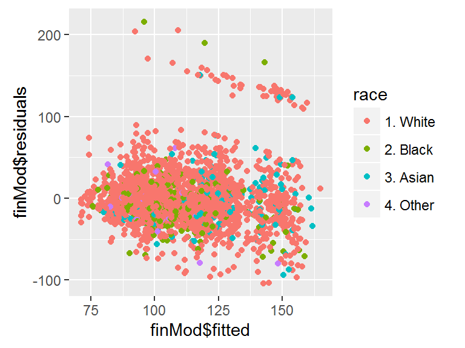

```r
# plot fitted values by residuals
qplot(finMod$fitted, finMod$residuals, color=race, data=training)
```

- plotting residuals by index (ie; row numbers) can be helpful in showing missing variables
  - `plot(finMod$residuals)` = plot the residuals against index (row number)
  - if there’s a trend/pattern in the residuals, it is highly likely that another variable (such as age/time) should be included.
    - residuals should not have relationship to index

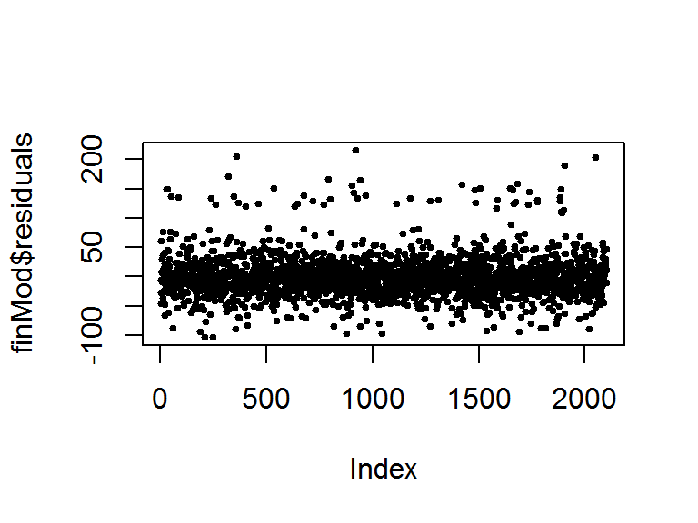

```r
# plot residual by index
plot(finMod$residuals,pch=19,cex=0.5)
```

$\pagebreak$

## Prediction with Trees

- **prediction with trees** = iteratively split variables into groups (effectively constructing decision trees) $\rightarrow$ produces nonlinear model
  - the classification tree uses interactions between variables $\rightarrow$ the ultimate groups/leafs may depend on many variables
- the result (tree) is easy to interpret, and generally performs better predictions than regression models when the relationships are *non-linear*
- transformations less important $\rightarrow$ monotone transformations (order unchanged, such as $\log$) will produce same splits
- trees can be used for regression problems as well and use RMSE as *measure of impurity*
- however, without proper cross-validation, the model can be *over-fitted* (especially with large number of variables) and results may be variable from one run to the next
  - it is also harder to estimate the uncertainty of the model
- `party`, `rpart`, `tree` packages can all build trees

### Process

1. start with all variables in one group
2. find the variable that best splits the outcomes into two groups
3. divide data into two groups (*leaves*) based on the split performed (*node*)
4. within each split, find variables to split the groups again
5. continue this process until all groups are sufficiently small/homogeneous/“pure”

### Measures of Impurity ([Reference](http://en.wikipedia.org/wiki/Decision_tree_learning))

$$\hat{p}_{mk} = \frac{\sum_{i}^m \mathbb{1}(y_i = k)}{N_m}$$

- $\hat p_mk$ is the probability of the objects in group $m$ to take on the classification $k$
- $N_m$ is the size of the group
- **Misclassification Error**
  $$1 - \hat{p}_{m~k(m)}$$
  where $k(m)$ is the most common classification/group
  - 0 = perfect purity
  - 0.5 = no purity
    - **Note**: it is not 1 here because when $\hat{p}_{m~k(m)} < 0.5$ or there’s not predominant classification for the objects, it means the group should be further subdivided until there’s a majority
- **Gini Index**
  $$\sum_{k \neq k'} \hat{p}_{mk} \times \hat{p}_{mk'} = \sum_{k=1}^K \hat{p}_{mk}(1-\hat{p}_{mk}) = 1 - \sum_{k=1}^K p_{mk}^2$$
  - 0 = perfect purity
  - 0.5 = no purity
- **Deviance**
  $$-\sum_{k=1}^K \hat{p}_{mk} \log_e\hat{p}_{mk}$$
  - 0 = perfect purity
  - 1 = no purity
- **Information Gai**
  $$-\sum_{k=1}^K \hat{p}_{mk} \log_2\hat{p}_{mk}$$
  - 0 = perfect purity
  - 1 = no purity
- *example*

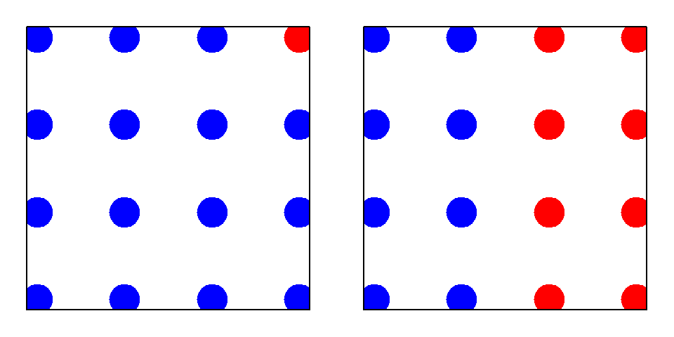

```r
# set margin and seed
par(mar=c(1,1,1,1), mfrow = c(1, 2)); set.seed(1234);
# simulate data
x = rep(1:4,each=4); y = rep(1:4,4)
# plot first scenario
plot(x,y,xaxt="n",yaxt="n",cex=3,col=c(rep("blue",15),rep("red",1)),pch=19)
# plot second scenario
plot(x,y,xaxt="n",yaxt="n",cex=3,col=c(rep("blue",8),rep("red",8)),pch=19)
```

### Constructing Trees with `caret` Package

- `tree<-train(y ~ ., data=train, method="rpart")` = constructs trees based on the outcome and predictors
  - produces an `rpart` object, which can be used to `predict` new/test values
  - `print(tree$finalModel)` = returns text summary of all nodes/splits in the tree constructed
- `plot(tree$finalModel, uniform=TRUE)` = plots the classification tree with all nodes/splits
  - [`rattle` package] `fancyRpartPlot(tree$finalModel)` = produces more readable, better formatted classification tree diagrams
  - each split will have the condition/node in bold and the splits/leafs on the left and right sides following the “yes” or “no” indicators
    - “yes” $\rightarrow$ go left
    - “no” $\rightarrow$ go right

```r
# load iris data set
data(iris)
# create test/train data sets
inTrain <- createDataPartition(y=iris$Species,p=0.7, list=FALSE)
training <- iris[inTrain,]
testing <- iris[-inTrain,]
# fit classification tree as a model
modFit <- train(Species ~ .,method="rpart",data=training)
# print the classification tree
print(modFit$finalModel)
```

```
## n= 105
##
## node), split, n, loss, yval, (yprob)
##       * denotes terminal node
##
## 1) root 105 70 setosa (0.33333333 0.33333333 0.33333333)
##   2) Petal.Length< 2.45 35  0 setosa (1.00000000 0.00000000 0.00000000) *
##   3) Petal.Length>=2.45 70 35 versicolor (0.00000000 0.50000000 0.50000000)
##     6) Petal.Width< 1.65 34  1 versicolor (0.00000000 0.97058824 0.02941176) *
##     7) Petal.Width>=1.65 36  2 virginica (0.00000000 0.05555556 0.94444444) *
```

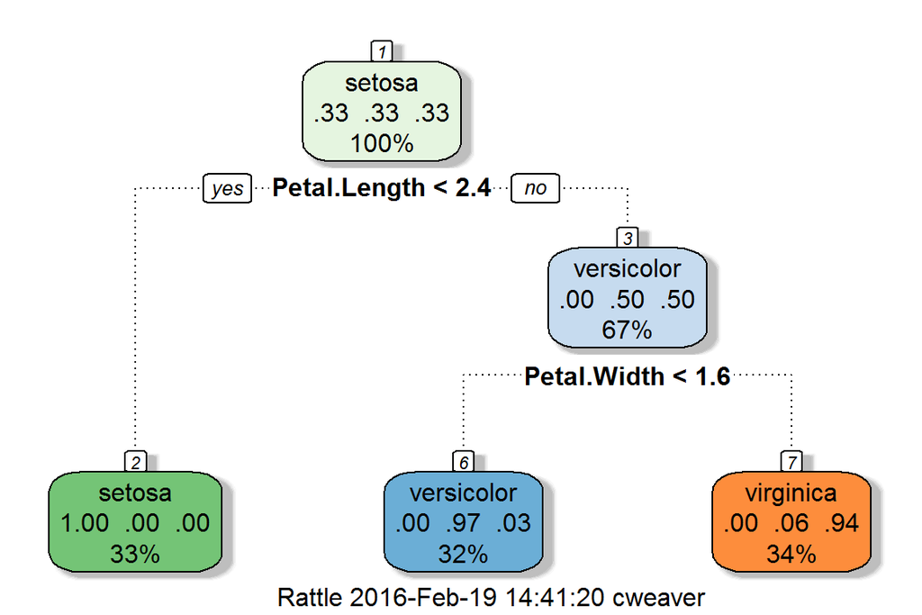

```r
# plot the classification tree
rattle::fancyRpartPlot(modFit$finalModel)
```

```r
# predict on test values
predict(modFit,newdata=testing)
```

```
##  [1] setosa     setosa     setosa     setosa     setosa     setosa
##  [7] setosa     setosa     setosa     setosa     setosa     setosa
## [13] setosa     setosa     setosa     versicolor versicolor versicolor
## [19] versicolor versicolor versicolor versicolor versicolor versicolor
## [25] versicolor versicolor versicolor versicolor versicolor versicolor
## [31] virginica  virginica  virginica  virginica  virginica  virginica
## [37] versicolor virginica  virginica  versicolor versicolor virginica
## [43] virginica  virginica  virginica
## Levels: setosa versicolor virginica
```

## Bagging

- **bagging** = bootstrap aggregating
  - resample training data set (with replacement) and recalculate predictions
  - average the predictions together or majority vote
  - more information can be found [here](http://stat.ethz.ch/education/semesters/FS_2008/CompStat/sk-ch8.pdf)
- averaging multiple complex models have *similar bias* as each of the models on its own, and *reduced variance* because of the average
- most useful for non-linear models
- *example*
  - `loess(y ~ x, data=train, span=0.2)` = fits a smooth curve to data
    - `span=0.2` = controls how smooth the curve should be

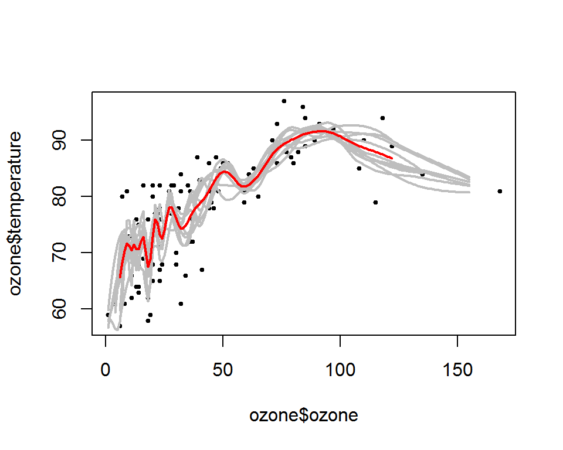

```r
# load data
library(ElemStatLearn); data(ozone,package="ElemStatLearn")
# reorder rows based on ozone variable
ozone <- ozone[order(ozone$ozone),]
# create empty matrix
ll <- matrix(NA,nrow=10,ncol=155)
# iterate 10 times
for(i in 1:10){
    # create sample from data with replacement
    ss <- sample(1:dim(ozone)[1],replace=T)
    # draw sample from the dataa and reorder rows based on ozone
    ozone0 <- ozone[ss,]; ozone0 <- ozone0[order(ozone0$ozone),]
    # fit loess function through data (similar to spline)
    loess0 <- loess(temperature ~ ozone,data=ozone0,span=0.2)
    # prediction from loess curve for the same values each time
    ll[i,] <- predict(loess0,newdata=data.frame(ozone=1:155))
}
# plot the data points
plot(ozone$ozone,ozone$temperature,pch=19,cex=0.5)
# plot each prediction model
for(i in 1:10){lines(1:155,ll[i,],col="grey",lwd=2)}
# plot the average in red
lines(1:155,apply(ll,2,mean),col="red",lwd=2)
```

### Bagging Algorithms

- in the `caret` package, there are three options for the `train` function to perform bagging
  - `bagEarth` - Bagged MARS ([documentation](http://www.inside-r.org/packages/cran/caret/docs/bagEarth))
  - `treebag` - Bagged CART ([documentation](http://www.inside-r.org/packages/cran/ipred/docs/bagging))
  - `bagFDA` - Bagged Flexible Discriminant Analysis ([documentation](http://www.inside-r.org/packages/cran/caret/docs/bagFDA))
- alternatively, custom `bag` functions can be constructed ([documentation](http://www.inside-r.org/packages/cran/caret/docs/nbBag))
  - `bag(predictors, outcome, B=10, bagControl(fit, predict, aggregate))` = define and execute custom bagging algorithm
    - `B=10` = iterations/resampling to perform
    - `bagControl()` = controls for how the bagging should be executed
      - `fit=ctreeBag$fit` = the model ran on each resampling of data
      - `predict=ctreeBag$predict` = how predictions should be calculated from each model
      - `aggregate=ctreeBag$aggregate` = how the prediction models should be combined/averaged
- *example*

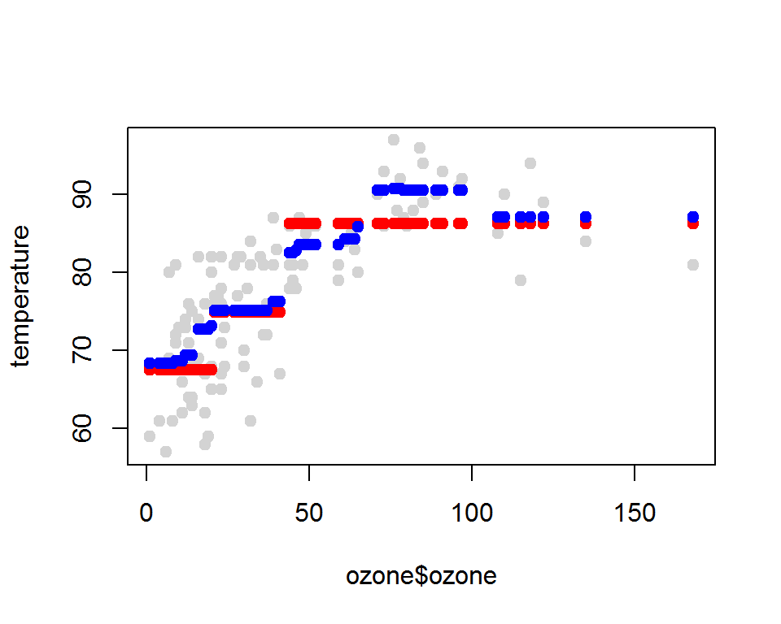

```r
# load relevant package and data
library(party); data(ozone,package="ElemStatLearn")
# reorder rows based on ozone variable
ozone <- ozone[order(ozone$ozone),]
# extract predictors
predictors <- data.frame(ozone=ozone$ozone)
# extract outcome
temperature <- ozone$temperature
# run bagging algorithm
treebag <- bag(predictors, temperature, B = 10,
                # custom bagging function
                bagControl = bagControl(fit = ctreeBag$fit,
                                        predict = ctreeBag$pred,
                                        aggregate = ctreeBag$aggregate))
# plot data points
plot(ozone$ozone,temperature,col='lightgrey',pch=19)
# plot the first fit
points(ozone$ozone,predict(treebag$fits[[1]]$fit,predictors),pch=19,col="red")
# plot the aggregated predictions
points(ozone$ozone,predict(treebag,predictors),pch=19,col="blue")
```

$\pagebreak$

## Random Forest

- **random forest** = extension of bagging on classification/regression trees
  - one of the most used/accurate algorithms along with boosting

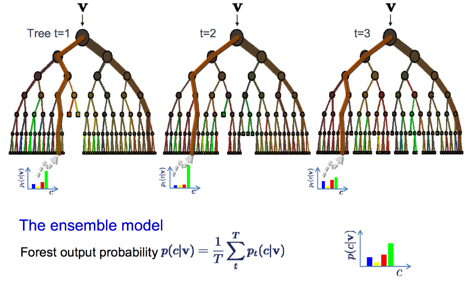

- **process**
  - bootstrap samples from training data (with replacement)
  - split and bootstrap variables
  - grow trees (repeat split/bootstrap) and vote/average final trees
- **drawbacks**
  - algorithm can be slow (process large number of trees)
  - hard to interpret (large numbers of splits and nodes)
  - over-fitting (difficult to know which tree is causing over-fitting)
  - **Note**: it is extremely important to use cross validation when running random forest algorithms